# turtle_commands

## turtle_commands

#### Question

1. A turtle starts at the central red dot facing North. It uses the following commands:
   - Character `F` means drag pen **Forward**
   - Character `+` means turn 90° right (clockwise)
   - Character `-` means turn 90° left (counterclockwise)
   - Character `X` means hop forward without drawing
   - Character `[` means save current position at top of pile
   - Character `]` means teleport to saved position (use position at top of pile and remove that position from pile)

   Use the following command string:

   `F[+FFFF]FFFFFFFF+FFFF[+FF]FFFFF`

   Which drawing is correct?

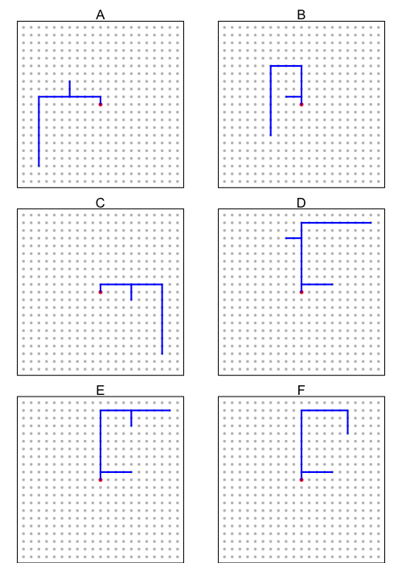

   1. A
   2. B
   3. C
   4. D
   5. E
   6. F

#### Question

2. A turtle starts at the central red dot facing North. It uses the following commands:
   - Character `F` means drag pen **Forward**
   - Character `+` means turn 90° right (clockwise)
   - Character `-` means turn 90° left (counterclockwise)
   - Character `X` means hop forward without drawing
   - Character `[` means save current position at top of pile
   - Character `]` means teleport to saved position (use position at top of pile and remove that position from pile)

   Use the following command string:

   `F[-FFFF]FFFFFFFF-FF-FFFFFFF`

   Which drawing is correct?

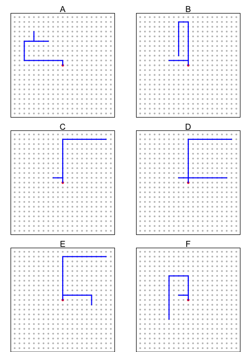

   1. A
   2. B
   3. C
   4. D
   5. E
   6. F

#### Question

3. A turtle starts at the central red dot facing North. It uses the following commands:
   - Character `F` means drag pen **Forward**
   - Character `+` means turn 90° right (clockwise)
   - Character `-` means turn 90° left (counterclockwise)
   - Character `X` means hop forward without drawing
   - Character `[` means save current position at top of pile
   - Character `]` means teleport to saved position (use position at top of pile and remove that position from pile)

   Use the following command string:

   `F-FFFF+FFFF+FFFF[+FF]FFFFF`

   Which drawing is correct?

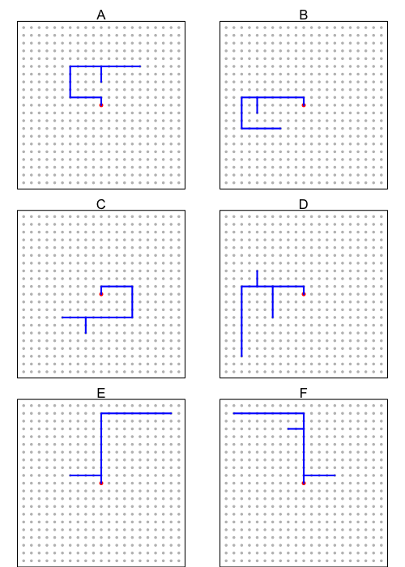

   1. A
   2. B
   3. C
   4. D
   5. E
   6. F

#### Question

4. A turtle starts at the central red dot facing North. It uses the following commands:
   - Character `F` means drag pen **Forward**
   - Character `+` means turn 90° right (clockwise)
   - Character `-` means turn 90° left (counterclockwise)
   - Character `X` means hop forward without drawing
   - Character `[` means save current position at top of pile
   - Character `]` means teleport to saved position (use position at top of pile and remove that position from pile)

   Use the following command string:

   `F-FFFF+FF[-FF]FF+FFFFFFFFF`

   Which drawing is correct?

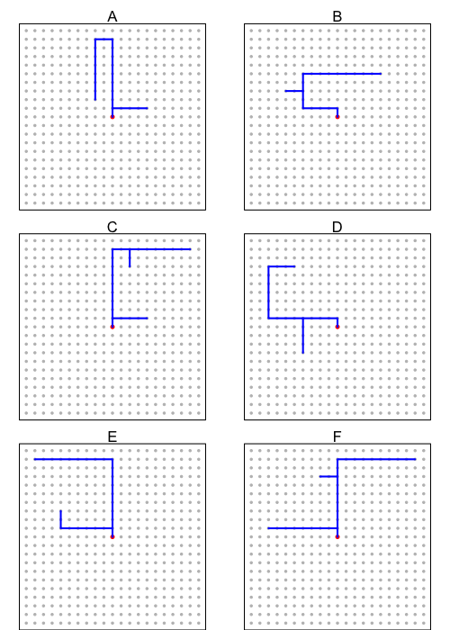

   1. A
   2. B
   3. C
   4. D
   5. E
   6. F

#### Question

5. A turtle starts at the central red dot facing North. It uses the following commands:
   - Character `F` means drag pen **Forward**
   - Character `+` means turn 90° right (clockwise)
   - Character `-` means turn 90° left (counterclockwise)
   - Character `X` means hop forward without drawing
   - Character `[` means save current position at top of pile
   - Character `]` means teleport to saved position (use position at top of pile and remove that position from pile)

   Use the following command string:

   `F[-FF[-FF]FFFFFF+FFFFFFFF]FFFFFFFF+FFFFFFFFF`

   Which drawing is correct?

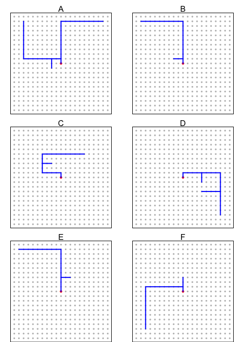

   1. A
   2. B
   3. C
   4. D
   5. E
   6. F

#### Question

6. A turtle starts at the central red dot facing North. It uses the following commands:
   - Character `F` means drag pen **Forward**
   - Character `+` means turn 90° right (clockwise)
   - Character `-` means turn 90° left (counterclockwise)
   - Character `X` means hop forward without drawing
   - Character `[` means save current position at top of pile
   - Character `]` means teleport to saved position (use position at top of pile and remove that position from pile)

   Use the following command string:

   `F[+FF]FFFFFFFF-FFFF-FFFFF`

   Which drawing is correct?

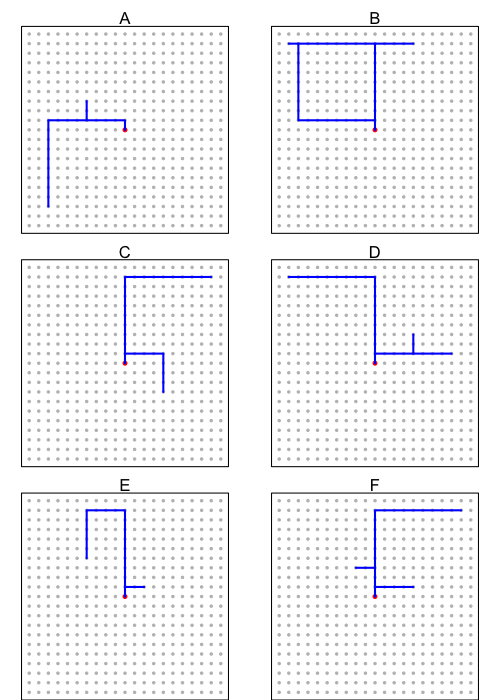

   1. A
   2. B
   3. C
   4. D
   5. E
   6. F